# Activity 06 - Simple Linear Regression Practice (Solutions)

STS 2300

Updated: 2024-09-29

We will use the following R packages for this activity.

```r
library(ggplot2)
library(Lock5Data)
```

For this activity, we’ll use a dataset called `RestaurantTips` from the `Lock5Data` R package. The data was collected by the owner of a bistro in New York and contains 157 bills at the restaurant over a two week period. Let’s explore the relationship between the size of the bill, called `Bill`, and the size of the tip, called `Tip`. Both variables are measured in dollars.

I’m going to read the data into R and call it `tips` to shorten the name a bit.

```r
tips <- RestaurantTips
```

1. Suppose we want to create a scatterplot comparing the size of the bill and the tip size. Which variable should be the explanatory variable and which should be the response variable? Why?

**Answer:** We will use the size of the bill (explanatory variable) to help us predict/explain the tip size (response variable). People use the bill size (which comes first) to determine their tip (which comes second).

2. Make a scatterplot comparing the bill size and the tip size. (Bonus: Consider adding a theme and making the labels nicer with `labs()`)

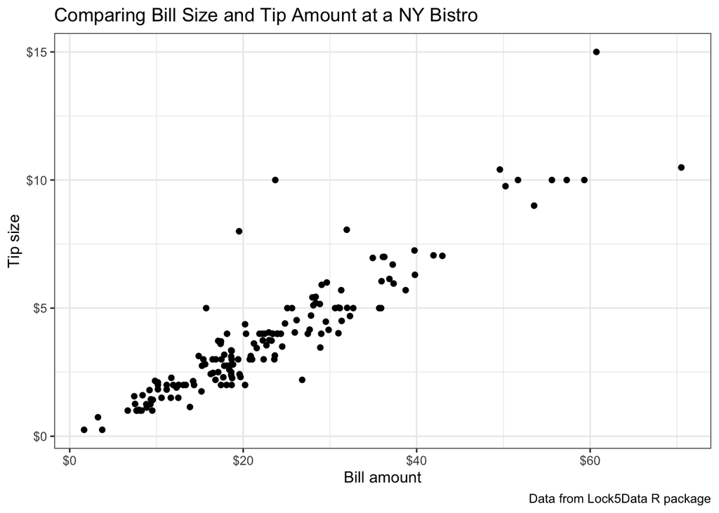

```r
ggplot(tips, aes(x = Bill, y = Tip)) +
  geom_point() +
  theme_bw() +
  scale_x_continuous(labels = scales::label_dollar()) +
  scale_y_continuous(labels = scales::label_dollar()) +
  labs(title = "Comparing Bill Size and Tip Amount at a NY Bistro",
       x = "Bill amount",
       y = "Tip size",
       caption = "Data from Lock5Data R package")
```

3. What do you notice about the relationship between the two variables?

**Answer:** Tip size tends to go up as the bill goes up. However, there are a few values further away from most of the others (usually above them). The relationship follows a straight line pattern pretty well.

4. Let’s use R to calculate a simple linear regression line for this data. Write the formula for the line after you run your R code. I’ve used R Markdown’s math mode to show you how you can write the general formula. You will just need to replace $b_0$ and $b_1$ with the numbers from your equation. You could also replace y and x with the variable names if you’d like.

```r
tips.lm <- lm(Tip ~ Bill, data = tips)
tips.lm
```

```
##
## Call:
## lm(formula = Tip ~ Bill, data = tips)
##
## Coefficients:
## (Intercept)         Bill
##     -0.2923       0.1822
```

**Formula:** $\widehat{Tip} = -0.2923 + 0.1822 * Bill$

5. Suppose you’re a server at the restaurant and someone has just spent $23.70 on a meal. How much would you predict their tip would be?

```r
# Option 1
 -0.2923 + 0.1822 * 23.7
```

```
## [1] 4.02584
```

```r
# Option 2
predict(tips.lm, newdata = data.frame(Bill = 23.7))
```

```
##        1
## 4.026222
```

**Prediction =** $4.03

6. There was one person in the dataset who actually did have a bill of $23.70. They left a $10 tip. What would be the residual for that observation?

```r
10 - 4.03
```

```
## [1] 5.97
```

**Residual =** $5.97

7. Would it be a good idea to use this data to predict the tip size for a $200 bill at this restaurant? Why or why not?

**Answer:** Not necessarily. The biggest value in our data set was a bill of $70.51. It’s possible that tipping habits differ when the bill becomes that large.

8. Would it be a good idea to use this data to predict the tip size for a $20 bill at The Root here in Elon? Why or why not?

**Answer:** Possibly. While this data was from a bistro in NY, there are generally accepted tipping practices that might apply here are The Root too.

9. You can add a simple linear regression line to your scatterplot by adding `geom_smooth(method = "lm", se = FALSE)` as another layer to your ggplot object. Try this out below. Can you find the observation whose residual we just calculated on the graph? (Note: You will need to respecify your x and y aesthetics in `geom_smooth()` or move them to the `ggplot()` function instead.)

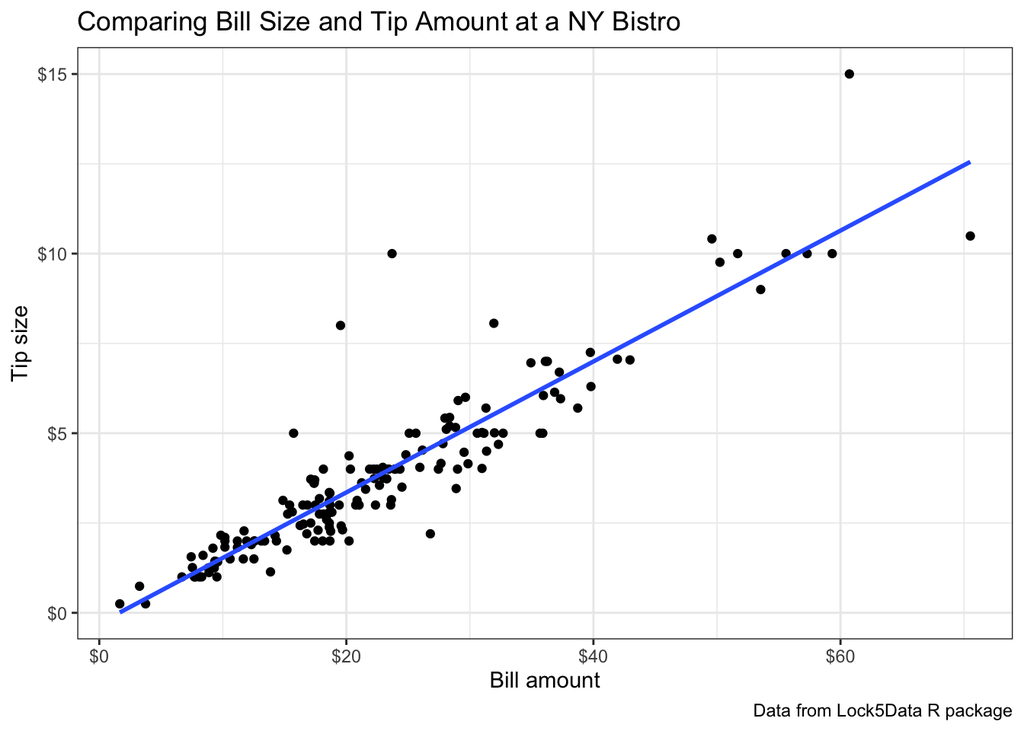

```r
ggplot(tips, aes(x = Bill, y = Tip)) +
  geom_point() +
  geom_smooth(method = "lm", se = FALSE) +
  theme_bw() +
  scale_x_continuous(labels = scales::label_dollar()) +
  scale_y_continuous(labels = scales::label_dollar()) +
  labs(title = "Comparing Bill Size and Tip Amount at a NY Bistro",
       x = "Bill amount",
       y = "Tip size",
       caption = "Data from Lock5Data R package")
```

10. Interpret the estimated y-intercept in context of this problem. Is this an extrapolation or an interpolation?

**Interpretation of y-intercept:** The predicted tip is -$0.29 for a bill of $0.00 at this bistro.

**Extrapolation or interpolation?:** This is an extrapolation (we can’t have a bill size of $0), and the result is clearly impossible.

11. Interpret the estimated slope in context of this problem.

**Interpretation of slope:** The predicted average tip goes up by $0.18 for every additional dollar spent on the bill (at this bistro in New York).

12. Does your estimated slope make sense based on what you know about tipping?

**Answer:** Yes! Standard tipping practices are generally to tip 15-20%, and this is in line with that.

13. Use the `summary()` function on the object created by the `lm()` function. Find the R-squared value in the output and write a sentence interpreting it.

```r
summary(tips.lm)
```

```
##
## Call:
## lm(formula = Tip ~ Bill, data = tips)
##
## Residuals:
##     Min      1Q  Median      3Q     Max
## -2.3911 -0.4891 -0.1108  0.2839  5.9738
##
## Coefficients:
##              Estimate Std. Error t value Pr(>|t|)
## (Intercept) -0.292267   0.166160  -1.759   0.0806 .
## Bill         0.182215   0.006451  28.247   <2e-16 ***
## ---
## Signif. codes:  0 '***' 0.001 '**' 0.01 '*' 0.05 '.' 0.1 ' ' 1
##
## Residual standard error: 0.9795 on 155 degrees of freedom
## Multiple R-squared:  0.8373, Adjusted R-squared:  0.8363
## F-statistic: 797.9 on 1 and 155 DF,  p-value: < 2.2e-16
```

**R-squared =** 0.8373

**Interpretation:** About 84% of the variability in tip size can be explained by bill size.

Bonus: Investigate how well the size of the bill can help predict the tip percentage (`PctTip`).

- Make a scatterplot. What is the relationship between the two variables? How does it compare to what we saw when we compared bill size to tip size (both in terms of dollars).
- Calculate a simple linear regression line and interpret the estimated intercept and estimated slope.